# briancen_OriginalHomeworkCode_03

Yongliang Cen

2025-02-27

```r
#Load the csv directly from Github
df <- read.csv("https://raw.githubusercontent.com/fuzzyatelin/fuzzyatelin.github.io/refs/heads/master/AN588_Spring25/zombies.csv")

#calculate the population mean and sd

# define a function to calculate population sd
pop_sd <- function(x) {
  m <- mean(x)
  sqrt(sum((x - m)^2) / length(x))
}

# create a list of variables that need to be calculated
random_var <- c("height", "weight", "age", "zombies_killed", "years_of_education")

# use for loop to calculate mean and sd for each random_var, df[[r]] is extracting the whole colmun as numeric vector so each value in the column will be called

for (r in random_var) {
  miu <- mean(df[[r]])
  sd <- pop_sd(df[[r]])
   cat("For", r, ",", "Population Mean =", miu, "and Population SD =", sd, "\n")
}
```

```
## For height , Population Mean = 67.6301 and Population SD = 4.30797
## For weight , Population Mean = 143.9075 and Population SD = 18.39186
## For age , Population Mean = 20.04696 and Population SD = 2.963583
## For zombies_killed , Population Mean = 2.992 and Population SD = 1.747551
## For years_of_education , Population Mean = 2.996 and Population SD = 1.675704
```

# Task 2

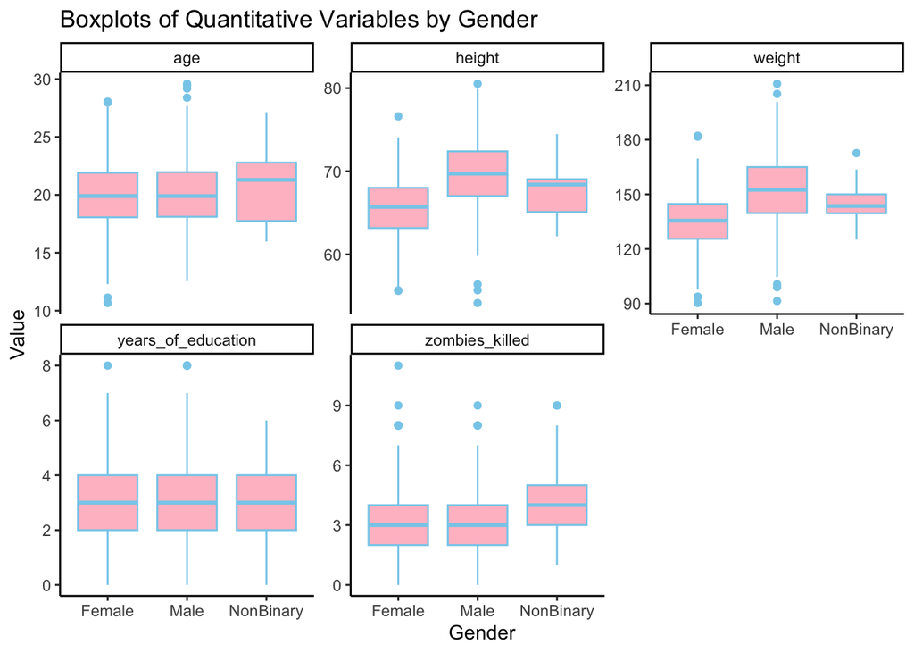

```r
library(tidyr)
library(ggplot2)

# reshape the data frame to make long format
df_long <- pivot_longer(df,
                        cols = c("height", "weight", "age", "zombies_killed", "years_of_education"),
                        names_to = "variable",
                        values_to = "value")

# plotting each quantitative variable by gender

ggplot(df_long, aes(x = gender, y = value)) +
  geom_boxplot(fill = "pink", color = "skyblue") +
  # facet look at the unique variables and create a "facet" aka subplot for them
  facet_wrap(~ variable, scales = "free_y") +
  theme_classic() +
  labs(title = "Boxplots of Quantitative Variables by Gender",
       x = "Gender",
       y = "Value")
```

# Task 3: create scatterplots of height and weight in relation to age

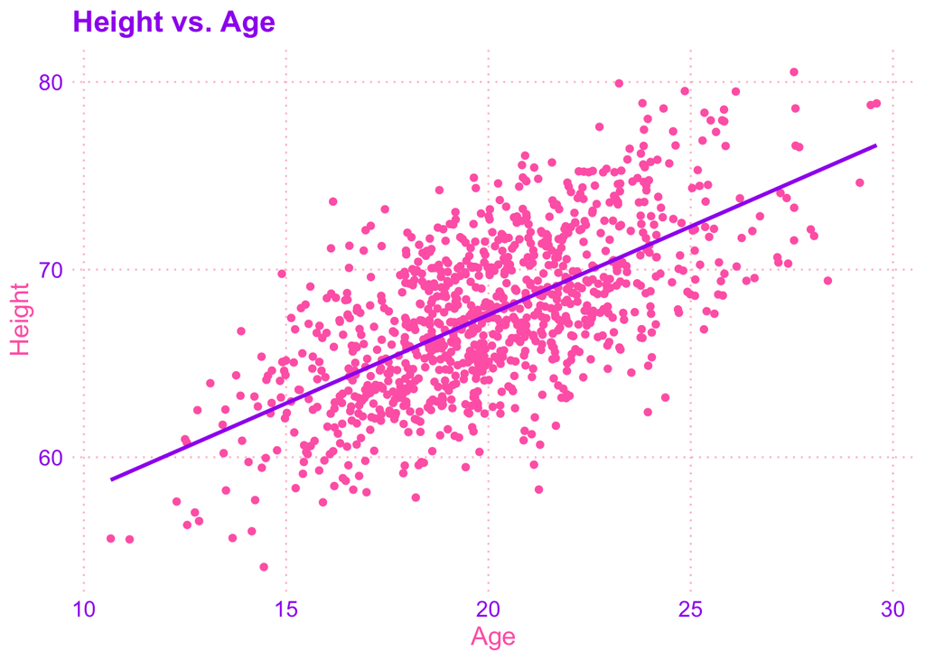

```r
# create scatter plot for height in relation to age
ggplot(df, aes(x = age, y = height)) +
  geom_point(color = "hotpink", size = 1.5) +
  geom_smooth(method = "lm", se = FALSE, color = "purple", size = 1) +
  labs(title = "Height vs. Age",
       x = "Age",
       y = "Height") +
  theme_minimal() +
  theme(
    plot.title = element_text(color = "purple", face = "bold", size = 16),
    axis.title = element_text(color = "hotpink", size = 14),
    axis.text = element_text(color = "purple", size = 12),
    panel.grid.major = element_line(color = "pink", linetype = "dotted"),
    panel.grid.minor = element_blank()
  )
```

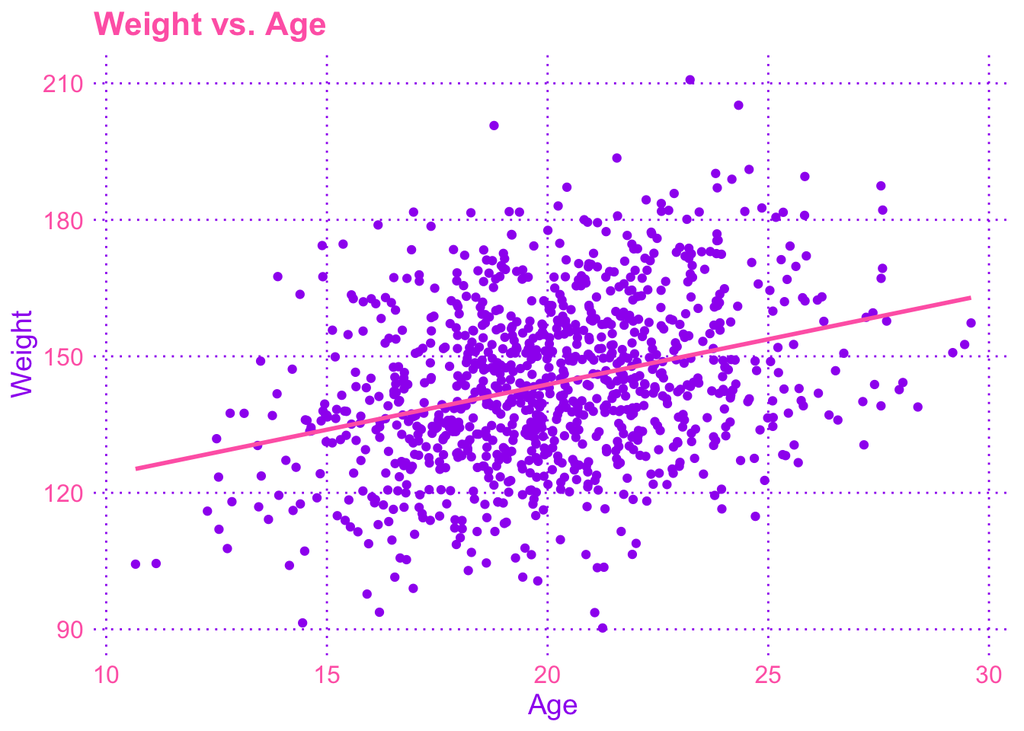

```r
# create scatter plot for weight in relation to age
ggplot(df, aes(x = age, y = weight)) +
  geom_point(color = "purple", size = 1.5) +
  geom_smooth(method = "lm", se = FALSE, color = "hotpink", size = 1) +
  labs(title = "Weight vs. Age",
       x = "Age",
       y = "Weight") +
  theme_minimal() +
  theme(
    plot.title = element_text(color = "hotpink", face = "bold", size = 16),
    axis.title = element_text(color = "purple", size = 14),
    axis.text = element_text(color = "hotpink", size = 12),
    panel.grid.major = element_line(color = "purple", linetype = "dotted"),
    panel.grid.minor = element_blank()
  )
```

Response: height and weight seems to increase with age, showing a positive correlation. However, most data points are around the age of 20 and within the age range there is a lot of fluctuation of both weight and height.

#Task4: create qq plot and histogram to check distribution

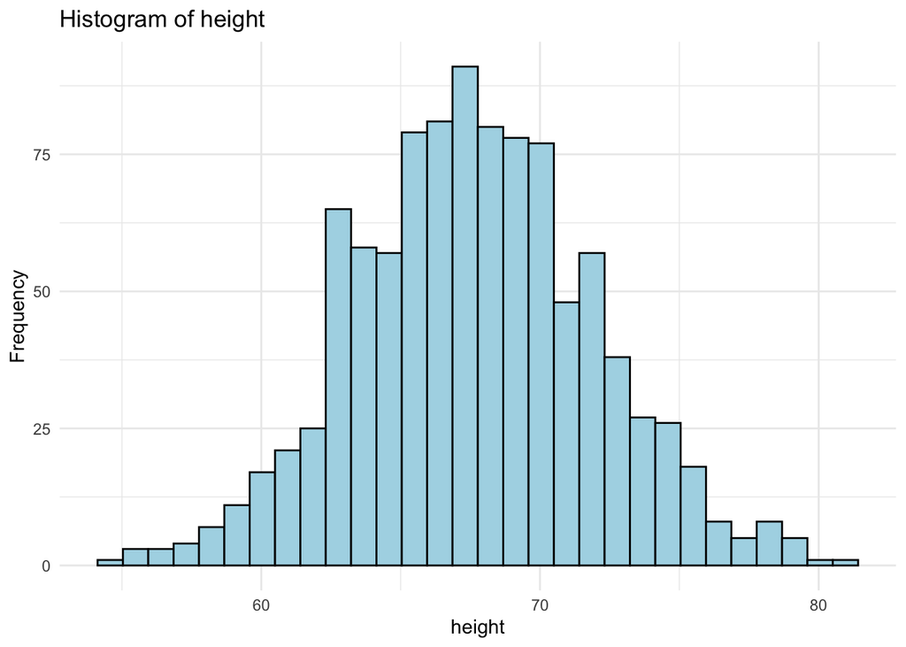

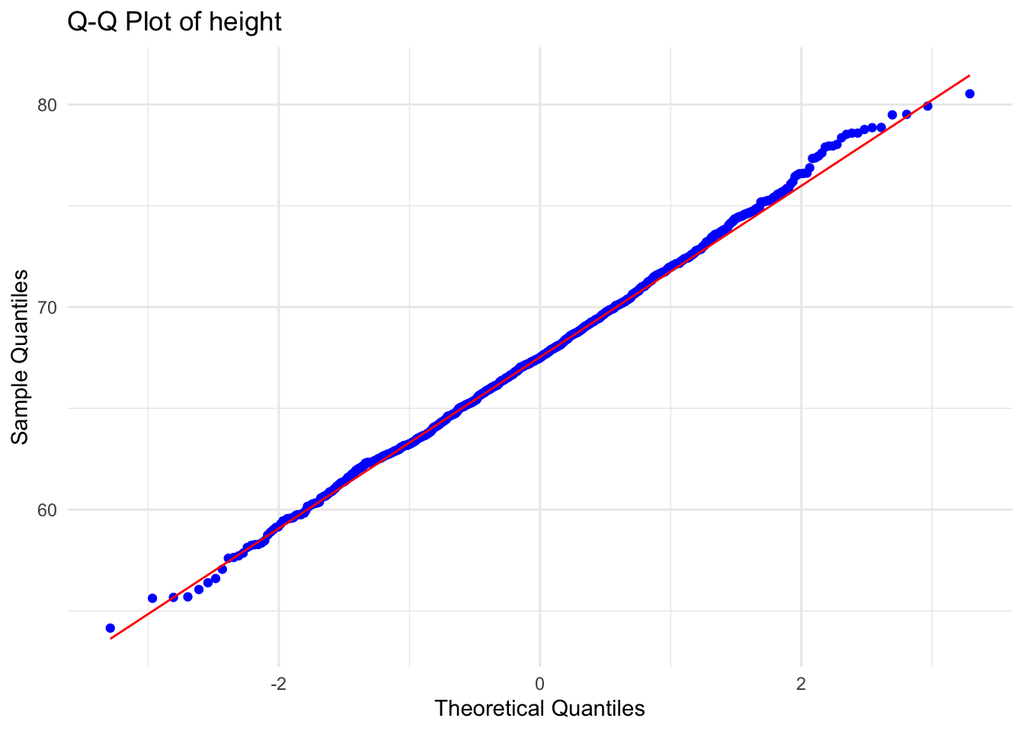

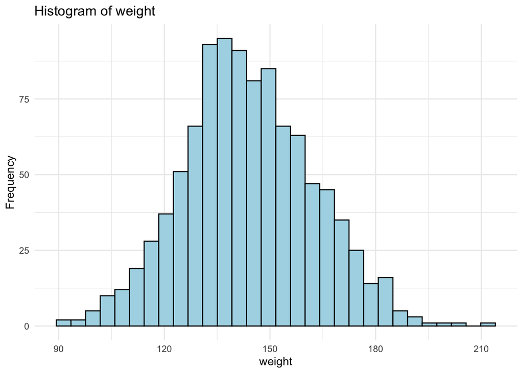

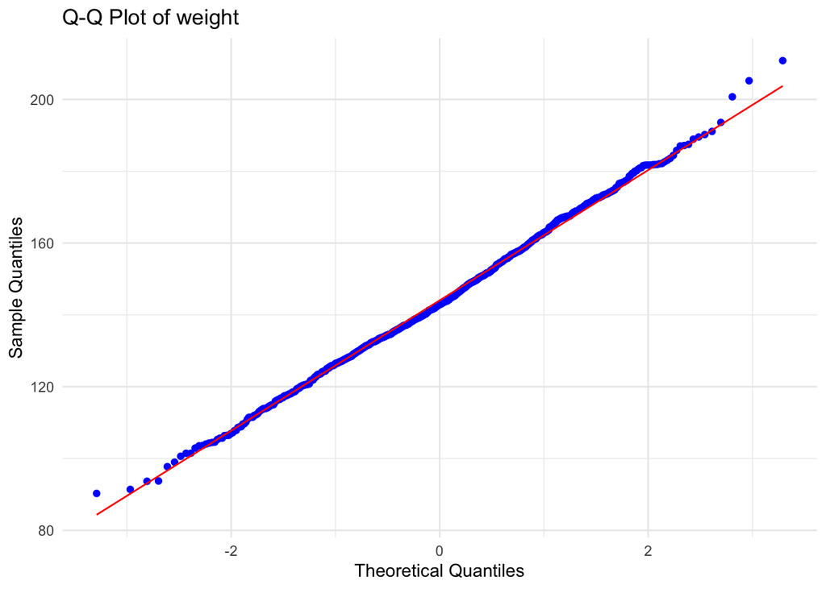

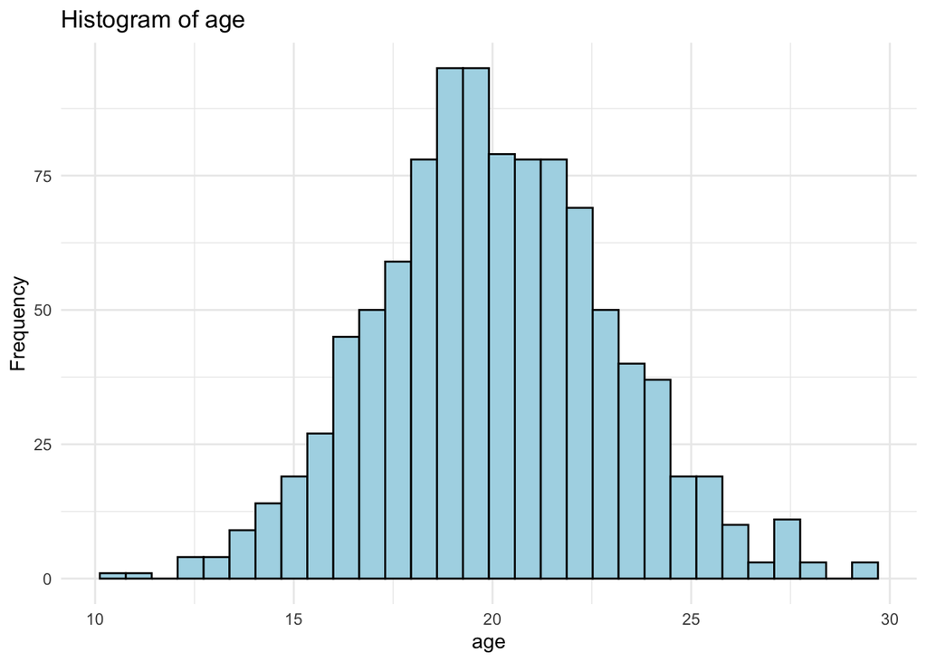

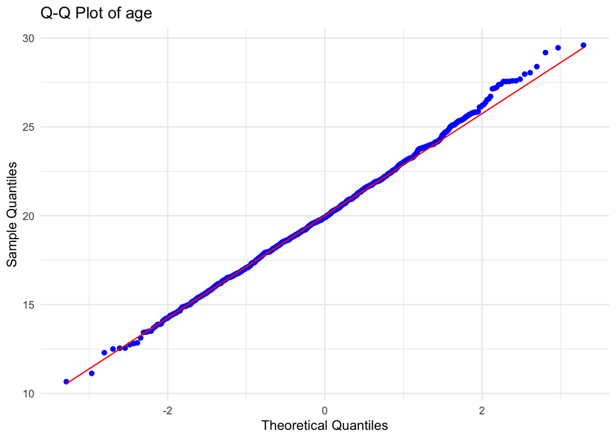

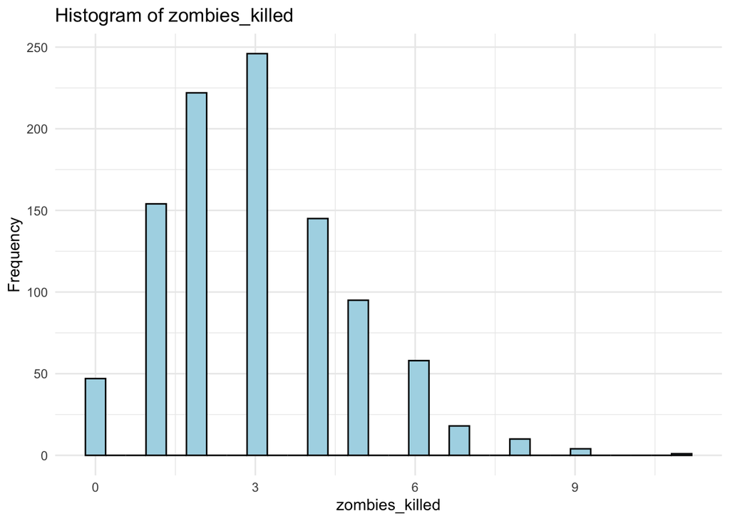

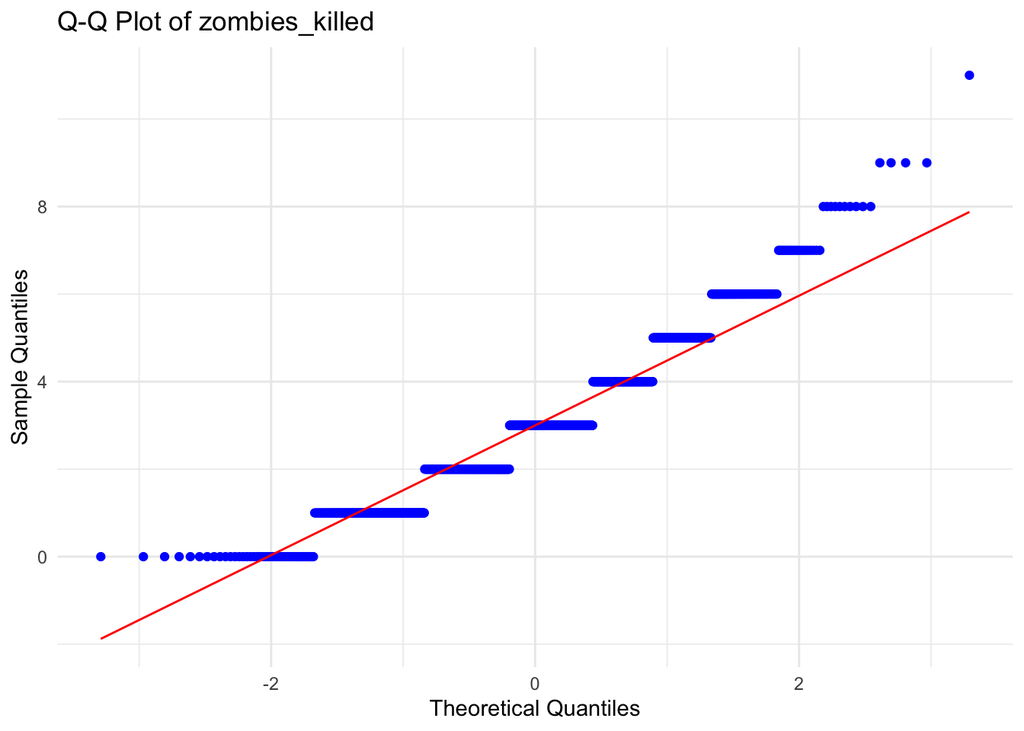

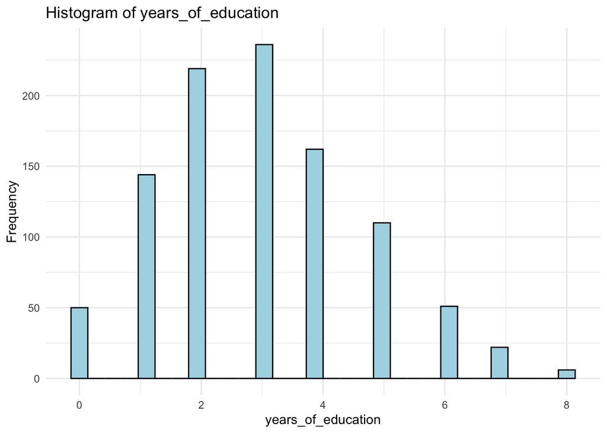

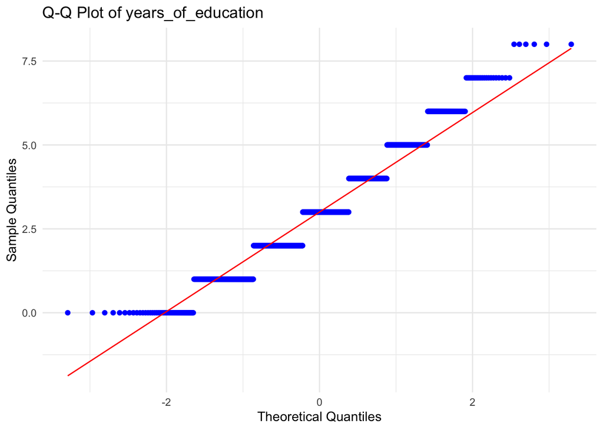

```r
for (r in random_var) {
 # loop over the quantitative variable to create histogram
  print(
    ggplot(df, aes(x = df[[r]])) +
      geom_histogram(bins = 30, fill = "lightblue", color = "black") +
      labs(title = paste("Histogram of", r),
           x = r, y = "Frequency") +
      theme_minimal()
  )

  ## loop over the quantitative variable to create qq plot
  print(
    ggplot(df, aes_string(sample = df[[r]])) +
      stat_qq(color = "blue") +
      stat_qq_line(color = "red") +
      labs(title = paste("Q-Q Plot of", r),
           x = "Theoretical Quantiles", y = "Sample Quantiles") +
      theme_minimal()
  )
}
```

Response: Height, weight and age seems to have normal distribution. Zombie kills and years of education are right skewed and they consist of discrete counting number. Thus, it suggest that the samples are from possion distribution. #Task5：sample 30

```r
set.seed(888)
df_sample <- df[sample(nrow(df), 30, replace = FALSE), ]


vars <- c("height", "weight", "age")

for (v in vars) {
  # Extract the data for this variable
  x <- df_sample[[v]]

  # 1) Sample mean
  xbar <- mean(x)

  # 2) Sample standard deviation
  s <- sd(x)

  # Sample size
  n <- length(x)

  # 3) Standard error
  se <- s / sqrt(n)

  # 4) 95% confidence interval using the t-distribution
  alpha <- 0.05
  df_t <- n - 1
  # Critical t-value for a two-sided 95% CI
  t_val <- qt(1 - alpha/2, df_t)
  ci_lower <- xbar - t_val * se
  ci_upper <- xbar + t_val * se

  cat("Variable:", v, "\n")
  cat("  Mean:", xbar, "\n")
  cat("  Sample SD:", s, "\n")
  cat("  SE:", se, "\n")
  cat("  95% CI:", "[", ci_lower, ",", ci_upper, "]\n\n")
}
```

```
## Variable: height
##   Mean: 66.54961
##   Sample SD: 3.976426
##   SE: 0.7259927
##   95% CI: [ 65.06479 , 68.03443 ]
##
## Variable: weight
##   Mean: 142.3891
##   Sample SD: 16.28673
##   SE: 2.973536
##   95% CI: [ 136.3075 , 148.4706 ]
##
## Variable: age
##   Mean: 19.02092
##   Sample SD: 2.939403
##   SE: 0.536659
##   95% CI: [ 17.92333 , 20.11851 ]
```

```r
## for non normal distributed variables
set.seed(10)

# I want to bootstrap 1000 replicates
boot_n <- 1000  # number of bootstrap replicates

# create a function to get a list of sampling mean
bootstrap_mean <- function(x, boot_n) {
  boot_means <- replicate(boot_n, {
    boot_sample <- sample(x, length(x), replace = TRUE)
    mean(boot_sample)
  })
  return(boot_means)
}

#--------------------------------
# Bootstrap for zombies killed
x_zombies <- df_sample$zombies_killed
boot_means_zombies <- bootstrap_mean(x_zombies, boot_n)

# Bootstrap estimates
boot_mean_zombies <- mean(boot_means_zombies)
boot_se_zombies <- sd(boot_means_zombies)
ci_zombies <- quantile(boot_means_zombies, c(0.025, 0.975))

cat("Zombies Killed:\n")
```

```
## Zombies Killed:
```

```r
cat("  Bootstrap Mean:", boot_mean_zombies, "\n")
```

```
##   Bootstrap Mean: 2.807133
```

```r
cat("  Bootstrap SE:", boot_se_zombies, "\n")
```

```
##   Bootstrap SE: 0.2289769
```

```r
cat("  95% CI: [", ci_zombies[1], ",", ci_zombies[2], "]\n\n")
```

```
##   95% CI: [ 2.366667 , 3.266667 ]
```

```r
#------------------------------------
# Bootstrap for years_of_education
x_education <- df_sample$years_of_education
boot_means_edu <- bootstrap_mean(x_education, boot_n)

# Bootstrap estimates
boot_mean_edu <- mean(boot_means_edu)
boot_se_edu <- sd(boot_means_edu)
ci_edu <- quantile(boot_means_edu, c(0.025, 0.975))

cat("Years of Education:\n")
```

```
## Years of Education:
```

```r
cat("  Bootstrap Mean:", boot_mean_edu, "\n")
```

```
##   Bootstrap Mean: 3.372933
```

```r
cat("  Bootstrap SE:", boot_se_edu, "\n")
```

```
##   Bootstrap SE: 0.3102423
```

```r
cat("  95% CI: [", ci_edu[1], ",", ci_edu[2], "]\n")
```

```
##   95% CI: [ 2.766667 , 3.9675 ]
```

#Task 6:

```r
library(tidyr)

vars <- c("height", "weight", "age", "zombies_killed", "years_of_education")

# Number of samples to draw
n_samples <- 100

# make a data frame with five columns each corresponding to the quantitative variables and 100 rows each for one of the sample mean and name the column with the variable names
sample_means <- data.frame(matrix(ncol = length(vars), nrow = n_samples))
colnames(sample_means) <- vars

set.seed(360)  # for reproducibility

# Draw 100 samples of 30 survivors and calculate means
for (i in 1:n_samples) {
  sample_i <- df[sample(nrow(df), 30, replace = FALSE), ]
  for (v in vars) {
    sample_means[i, v] <- mean(sample_i[[v]])
  }
}

# Calculate the overall mean and standard deviation (SD) of the sampling distribution for each variable
sampling_result <- sapply(sample_means, function(x) c(mean = mean(x), sd = sd(x)))
print(sampling_result)
```

```
##          height     weight        age zombies_killed years_of_education
## mean 67.6713538 143.805273 20.0862621      3.0323333          3.0156667
## sd    0.7859644   3.472351  0.5162717      0.3211041          0.3204744
```

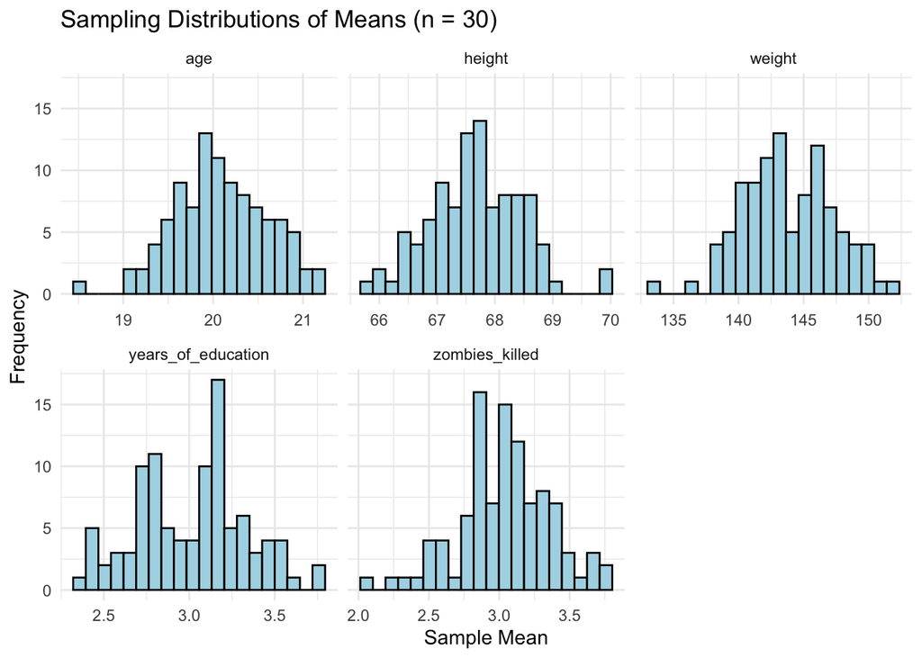

```r
# Plot the sampling distributions using histograms:
sample_means_long <- pivot_longer(sample_means, cols = all_of(vars),
                                  names_to = "variable", values_to = "sample_mean")

ggplot(sample_means_long, aes(x = sample_mean)) +
  geom_histogram(bins = 20, fill = "lightblue", color = "black") +
  facet_wrap(~ variable, scales = "free_x") +
  labs(title = "Sampling Distributions of Means (n = 30)",
       x = "Sample Mean",
       y = "Frequency") +
  theme_minimal()
```

response: The means, SD and SE from [5] is not far from that from [6]. However, since [5] from only one observation, it can not represent the true popultion mean, SD and SE as well as the sampling distribution. The smapling distributions for all variables are about normal distributed which is exactly what the central limit theorem tells us. Regradless of the original sample distribution, as long as the sample size is large enough, the distribution of the sample mean tends to be normal.